# EPA4T2016

Benito Velasco

29 de marzo de 2017

### Descarga y lectura del fichero EPA

##### readr, plyr,dplyr,highr,rmarkdown,reshape2,stringi,formatR

### Dividimos por 100 la variable FACTOREL para reducirla a unidades y calculamos el total poblacional.

```r
epa176$FACTOREL<-epa176$FACTOREL/100
Poblacion<-sum(epa176$FACTOREL)
summary(epa176$FACTOREL)
```

```
##    Min. 1st Qu.  Median    Mean 3rd Qu.    Max.
##   11.41  152.10  226.60  289.60  359.30 2851.00
```

```r
Poblacion
```

```
## [1] 46019618
```

### Filtramos el fichero por las variables que nos interesan les damos nuevos nombres:

CCAA,EDAD5,SEXO1,NAC1,NFORMA,AOI,FACTOREL.

```r
library(plyr); library(dplyr)

epa_sel<-select(epa176,CCAA,EDAD5,SEXO1,NAC1, NFORMA,AOI,FACTOREL)


glimpse(epa_sel)
```

```
## Observations: 158,915
## Variables: 7
## $ CCAA     <chr> "16", "16", "16", "16", "16", "16", "16", "16", "16",...
## $ EDAD5    <dbl> 40, 35, 35, 40, 40, 0, 40, 40, 45, 16, 45, 40, 40, 45...
## $ SEXO1    <chr> "1", "6", "1", "1", "6", "6", "1", "1", "6", "1", "6"...
## $ NAC1     <chr> "1", "1", "1", "1", "1", "1", "1", "1", "1", "1", "1"...
## $ NFORMA   <chr> "S1", "SU", "SP", "SP", "SU", NA, "SU", "S1", "S1", "...
## $ AOI      <chr> "03", "04", "04", "04", "03", NA, "04", "04", "03", "...
## $ FACTOREL <dbl> 274.46, 213.05, 213.05, 235.52, 235.52, 209.10, 274.4...
```

### Creamos una nueva variable “ACTIVIDAD” que identifica la situación respecto del empleo

```r
epa_sel<-epa_sel%>%mutate(ACTIVIDAD=cut(as.numeric(AOI),breaks=c(0,4,6,9),labels=c("Ocupados","Parados","Inactivos")))
```

### Creamos una nueva variable “ESTUDIOS” que agrupa e identifica los niveles de estudio

```r
epa_sel$NFORMA <- mapvalues(epa_sel$NFORMA, from = c('AN','P1','P2','S1','SG','SP','SU'), to = c('01','02','03','04','05','06','07'))

epa_sel<-epa_sel%>%mutate(ESTUDIOS=cut(as.numeric(NFORMA),breaks=c(0,1,3,6,7),labels=c("Analfabetos","E. Primarios","E. Secundarios","E. Universitarios")))
```

### Creamos una nueva variable “GRUPO_EDAD” que reduce y explicita los grupos de edad

```r
epa_sel<-epa_sel%>%mutate(GRUPO_EDAD=cut(as.numeric(EDAD5),breaks=c(-1,10,16,25,35,45,55,65),labels=c("Menores de 16 años","De 16 a 20 años","De 20 a 29 años","De 30 a 39 años","De 40 a 49 años","De 50 a 59 años","Mayores de 60 años")))

muestra_edad<-as.data.frame(table(epa_sel$GRUPO_EDAD))

library(knitr)

kable(muestra_edad, align=c('l','r'),caption = "Distribución de la muestra por edades",format.args = list(decimal.mark = ",", big.mark = "."))
```

Distribución de la muestra por edades

| Var1 | Freq |
| --- | --- |
| Menores de 16 años | 24.503 |
| De 16 a 20 años | 6.441 |
| De 20 a 29 años | 14.832 |
| De 30 a 39 años | 18.683 |
| De 40 a 49 años | 24.419 |
| De 50 a 59 años | 24.505 |
| Mayores de 60 años | 45.532 |

#### Eliminamos variables redundantes

```r
epa_sel<-epa_sel%>%select(-EDAD5,-NFORMA,-AOI)
glimpse(epa_sel)
```

```
## Observations: 158,915
## Variables: 7
## $ CCAA       <chr> "16", "16", "16", "16", "16", "16", "16", "16", "16...
## $ SEXO1      <chr> "1", "6", "1", "1", "6", "6", "1", "1", "6", "1", "...
## $ NAC1       <chr> "1", "1", "1", "1", "1", "1", "1", "1", "1", "1", "...
## $ FACTOREL   <dbl> 274.46, 213.05, 213.05, 235.52, 235.52, 209.10, 274...
## $ ACTIVIDAD  <fctr> Ocupados, Ocupados, Ocupados, Ocupados, Ocupados, ...
## $ ESTUDIOS   <fctr> E. Secundarios, E. Universitarios, E. Secundarios,...
## $ GRUPO_EDAD <fctr> De 40 a 49 años, De 30 a 39 años, De 30 a 39 años,...
```

```r
colnames(epa_sel)[2:3]<-c("SEXO", "NACIONALIDAD")


epa_sel$CCAA<-as.factor(epa_sel$CCAA)
epa_sel$SEXO<-as.factor(epa_sel$SEXO)
epa_sel$NACIONALIDAD<-as.factor(epa_sel$NACIONALIDAD)

glimpse(epa_sel)
```

```
## Observations: 158,915
## Variables: 7
## $ CCAA         <fctr> 16, 16, 16, 16, 16, 16, 16, 16, 16, 16, 16, 16, ...
## $ SEXO         <fctr> 1, 6, 1, 1, 6, 6, 1, 1, 6, 1, 6, 6, 1, 1, 1, 6, ...
## $ NACIONALIDAD <fctr> 1, 1, 1, 1, 1, 1, 1, 1, 1, 1, 1, 1, 1, 1, 1, 1, ...
## $ FACTOREL     <dbl> 274.46, 213.05, 213.05, 235.52, 235.52, 209.10, 2...
## $ ACTIVIDAD    <fctr> Ocupados, Ocupados, Ocupados, Ocupados, Ocupados...
## $ ESTUDIOS     <fctr> E. Secundarios, E. Universitarios, E. Secundario...
## $ GRUPO_EDAD   <fctr> De 40 a 49 años, De 30 a 39 años, De 30 a 39 año...
```

#### Agrupamos las observaciones por todas las variables de nuestro interés (CCAA, SEXO, ACTIVIDAD, ESTUDIOS,GRUPO_EDAD)y obtenemos los totales poblacionales para cada combinación posible

```r
tablas_EPA<-epa_sel%>%group_by(CCAA,SEXO,NACIONALIDAD,ACTIVIDAD,ESTUDIOS,GRUPO_EDAD)%>%summarise(Total=sum(FACTOREL))

#Reordenamos las columnas
tablas_EPA<-select(tablas_EPA,CCAA,SEXO,GRUPO_EDAD,ESTUDIOS,NACIONALIDAD,ACTIVIDAD,TOTAL=Total)

glimpse(tablas_EPA)
```

```
## Observations: 4,360
## Variables: 7
## $ CCAA         <fctr> 01, 01, 01, 01, 01, 01, 01, 01, 01, 01, 01, 01, ...
## $ SEXO         <fctr> 1, 1, 1, 1, 1, 1, 1, 1, 1, 1, 1, 1, 1, 1, 1, 1, ...
## $ GRUPO_EDAD   <fctr> De 40 a 49 años, De 50 a 59 años, Mayores de 60 ...
## $ ESTUDIOS     <fctr> Analfabetos, Analfabetos, Analfabetos, E. Primar...
## $ NACIONALIDAD <fctr> 1, 1, 1, 1, 1, 1, 1, 1, 1, 1, 1, 1, 1, 1, 1, 1, ...
## $ ACTIVIDAD    <fctr> Ocupados, Ocupados, Ocupados, Ocupados, Ocupados...
## $ TOTAL        <dbl> 220.23, 260.98, 1061.38, 469.66, 14839.38, 14499....
```

#### Sustituimos los valores de CCAA, SEXO y NACIONALIDAD por sus literales

```r
tablas_EPA$CCAA <- mapvalues(tablas_EPA$CCAA, from = c('01','02','03','04','05','06','07','08','09','10', '11','12','13','14','15','16','17','51','52'), to = c('01  Andalucía', '02  Aragón', '03  Asturias', '04  Baleares', '05  Canarias', '06  Cantabria', '07  Castilla-León', '08  Castilla-La Mancha', '09  Cataluña', '10  Comunidad Valenciana', '11  Extremadura', '12  Galicia', '13  Madrid', '14  Murcia', '15  Navarra', '16  País Vasco', '17  Rioja, La','51  Ceuta','52  Melilla '))

tablas_EPA$SEXO <- mapvalues(tablas_EPA$SEXO, from = c('1','6'), to = c('Varones', 'Mujeres'))

tablas_EPA$NACIONALIDAD <-mapvalues(tablas_EPA$NACIONALIDAD, from = c('1','2','3'), to = c('Española','Española y doble nacionalidad','Extranjera'))

kable(head(tablas_EPA), caption = "Distribución de la población por todas las variables de interés", format.args = list(decimal.mark = ",", big.mark = "."))
```

Distribución de la población por todas las variables de interés

| CCAA | SEXO | GRUPO_EDAD | ESTUDIOS | NACIONALIDAD | ACTIVIDAD | TOTAL |
| --- | --- | --- | --- | --- | --- | --- |
| 01 Andalucía | Varones | De 40 a 49 años | Analfabetos | Española | Ocupados | 220,23 |
| 01 Andalucía | Varones | De 50 a 59 años | Analfabetos | Española | Ocupados | 260,98 |
| 01 Andalucía | Varones | Mayores de 60 años | Analfabetos | Española | Ocupados | 1.061,38 |
| 01 Andalucía | Varones | De 16 a 20 años | E. Primarios | Española | Ocupados | 469,66 |
| 01 Andalucía | Varones | De 20 a 29 años | E. Primarios | Española | Ocupados | 14.839,38 |
| 01 Andalucía | Varones | De 30 a 39 años | E. Primarios | Española | Ocupados | 14.499,41 |

#### Ordenamos las filas de datos por los valores de las sucesivas columnas

```r
tablas_EPA<-arrange(tablas_EPA,CCAA,SEXO,GRUPO_EDAD,ESTUDIOS,NACIONALIDAD,ACTIVIDAD)

kable(head(tablas_EPA), caption = "Distribución de la población por todas las variables de interés", format.args = list(decimal.mark = ",", big.mark = "."))
```

Distribución de la población por todas las variables de interés

| CCAA | SEXO | GRUPO_EDAD | ESTUDIOS | NACIONALIDAD | ACTIVIDAD | TOTAL |
| --- | --- | --- | --- | --- | --- | --- |
| 01 Andalucía | Varones | Menores de 16 años | NA | Española | NA | 720.928,09 |
| 01 Andalucía | Varones | Menores de 16 años | NA | Española y doble nacionalidad | NA | 10.080,77 |
| 01 Andalucía | Varones | Menores de 16 años | NA | Extranjera | NA | 14.913,55 |
| 01 Andalucía | Varones | De 16 a 20 años | Analfabetos | Española | Inactivos | 384,10 |
| 01 Andalucía | Varones | De 16 a 20 años | E. Primarios | Española | Ocupados | 469,66 |
| 01 Andalucía | Varones | De 16 a 20 años | E. Primarios | Española | Parados | 2.049,88 |

#### Eliminamos los menores de 16 años

```r
tablas_EPA<-tablas_EPA%>%filter(GRUPO_EDAD!="Menores de 16 años")

kable(head(tablas_EPA), caption = "Distribución de los mayores de 16 años por todas las variables de interés", format.args = list(decimal.mark = ",", big.mark = "."))
```

Distribución de los mayores de 16 años por todas las variables de interés

| CCAA | SEXO | GRUPO_EDAD | ESTUDIOS | NACIONALIDAD | ACTIVIDAD | TOTAL |
| --- | --- | --- | --- | --- | --- | --- |
| 01 Andalucía | Varones | De 16 a 20 años | Analfabetos | Española | Inactivos | 384,10 |
| 01 Andalucía | Varones | De 16 a 20 años | E. Primarios | Española | Ocupados | 469,66 |
| 01 Andalucía | Varones | De 16 a 20 años | E. Primarios | Española | Parados | 2.049,88 |
| 01 Andalucía | Varones | De 16 a 20 años | E. Primarios | Española | Inactivos | 9.391,29 |
| 01 Andalucía | Varones | De 16 a 20 años | E. Primarios | Extranjera | Inactivos | 1.485,19 |
| 01 Andalucía | Varones | De 16 a 20 años | E. Secundarios | Española | Ocupados | 4.995,43 |

```r
library(reshape2)
Valores<-dcast(tablas_EPA,CCAA+SEXO+GRUPO_EDAD+ESTUDIOS+NACIONALIDAD ~ ACTIVIDAD,value.var = "TOTAL")
```

#### Calculamos valores absolutos y relativos de empleo , paro e inactividad para el Conjunto Nacional

```r
TotalNac_EPA<-Valores%>%summarise(
  Total_Ocupados=round(sum(Ocupados,na.rm = TRUE),1),
  Total_Parados=round(sum(Parados,na.rm = TRUE),1),
  Total_Activos=Total_Ocupados+Total_Parados,
  Tasa_desempleo=round(100*(Total_Parados/Total_Activos),2),
  Total_Inactivos=sum(Inactivos,na.rm = TRUE),
  Tasa_actividad=round(100*Total_Activos/(Total_Activos+Total_Inactivos),2))

kable(TotalNac_EPA, caption = "Población mayor de 16 años según su relación con la Actividad. Total Nacional", format.args = list(decimal.mark = ",", big.mark = "."))
```

Población mayor de 16 años según su relación con la Actividad. Total Nacional

| Total_Ocupados | Total_Parados | Total_Activos | Tasa_desempleo | Total_Inactivos | Tasa_actividad |
| --- | --- | --- | --- | --- | --- |
| 18.508.095 | 4.237.799 | 22.745.894 | 18,63 | 15.839.027 | 58,95 |

#### Calculamos valores absolutos y relativos de empleo , paro e inactividad por CCAA

```r
TablaCCAA_EPA<-Valores%>%group_by(CCAA)%>%summarise(
  Total_Ocupados=round(sum(Ocupados,na.rm = TRUE),1),
  Total_Parados=round(sum(Parados,na.rm = TRUE),1),
  Total_Activos=Total_Ocupados+Total_Parados,
  Tasa_desempleo=round(100*(Total_Parados/Total_Activos),2),
  Total_Inactivos=sum(Inactivos,na.rm = TRUE),
  Tasa_actividad=round(100*Total_Activos/(Total_Activos+Total_Inactivos),2))

kable(TablaCCAA_EPA, caption = "Población mayor de 16 años según su relación con la Actividad. Comunidades Autónomas", format.args = list(decimal.mark = ",", big.mark = "."))
```

Población mayor de 16 años según su relación con la Actividad. Comunidades Autónomas

| CCAA | Total_Ocupados | Total_Parados | Total_Activos | Tasa_desempleo | Total_Inactivos | Tasa_actividad |
| --- | --- | --- | --- | --- | --- | --- |
| 01 Andalucía | 2.845.256,2 | 1.120.305,7 | 3.965.561,9 | 28,25 | 2.935.235,79 | 57,47 |
| 02 Aragón | 560.840,8 | 87.782,1 | 648.622,9 | 13,53 | 446.944,82 | 59,20 |
| 03 Asturias | 393.757,9 | 67.254,4 | 461.012,3 | 14,59 | 444.669,45 | 50,90 |
| 04 Baleares | 511.640,3 | 81.875,9 | 593.516,2 | 13,80 | 356.076,68 | 62,50 |
| 05 Canarias | 826.280,0 | 273.986,0 | 1.100.266,0 | 24,90 | 705.553,67 | 60,93 |
| 06 Cantabria | 240.819,9 | 35.650,3 | 276.470,2 | 12,89 | 215.479,16 | 56,20 |
| 07 Castilla-León | 972.866,3 | 169.132,5 | 1.141.998,8 | 14,81 | 934.997,56 | 54,98 |
| 08 Castilla-La Mancha | 770.146,4 | 219.021,6 | 989.168,0 | 22,14 | 692.017,59 | 58,84 |
| 09 Cataluña | 3.202.613,2 | 558.457,1 | 3.761.070,3 | 14,85 | 2.340.719,02 | 61,64 |
| 10 Comunidad Valenciana | 1.973.843,8 | 467.371,5 | 2.441.215,3 | 19,15 | 1.661.873,04 | 59,50 |
| 11 Extremadura | 357.966,9 | 141.349,4 | 499.316,3 | 28,31 | 409.637,55 | 54,93 |
| 12 Galicia | 1.049.575,2 | 204.192,7 | 1.253.767,9 | 16,29 | 1.095.520,89 | 53,37 |
| 13 Madrid | 2.860.834,6 | 489.109,9 | 3.349.944,5 | 14,60 | 1.951.893,07 | 63,18 |
| 14 Murcia | 571.596,3 | 130.453,6 | 702.049,9 | 18,58 | 486.191,61 | 59,08 |
| 15 Navarra | 277.331,8 | 30.836,3 | 308.168,1 | 10,01 | 214.962,15 | 58,91 |
| 16 País Vasco | 902.104,9 | 126.189,2 | 1.028.294,1 | 12,27 | 786.500,49 | 56,66 |
| 17 Rioja, La | 135.765,9 | 16.617,0 | 152.382,9 | 10,90 | 106.785,13 | 58,80 |
| 51 Ceuta | 27.867,9 | 8.040,4 | 35.908,3 | 22,39 | 29.036,49 | 55,29 |
| 52 Melilla | 26.986,2 | 10.173,1 | 37.159,3 | 27,38 | 24.932,61 | 59,85 |

#### Unimos ambas tablas

```r
TablaNACIONAL_EPA<-TotalNac_EPA%>%mutate(CCAA="Conjunto Nacional")
glimpse(TablaCCAA_EPA)
```

```
## Observations: 19
## Variables: 7
## $ CCAA            <fctr> 01  Andalucía, 02  Aragón, 03  Asturias, 04  ...
## $ Total_Ocupados  <dbl> 2845256.2, 560840.8, 393757.9, 511640.3, 82628...
## $ Total_Parados   <dbl> 1120305.7, 87782.1, 67254.4, 81875.9, 273986.0...
## $ Total_Activos   <dbl> 3965561.9, 648622.9, 461012.3, 593516.2, 11002...
## $ Tasa_desempleo  <dbl> 28.25, 13.53, 14.59, 13.80, 24.90, 12.89, 14.8...
## $ Total_Inactivos <dbl> 2935235.79, 446944.82, 444669.45, 356076.68, 7...
## $ Tasa_actividad  <dbl> 57.47, 59.20, 50.90, 62.50, 60.93, 56.20, 54.9...
```

```r
TablaNACIONAL_EPA<-TablaNACIONAL_EPA%>%select(CCAA,Total_Ocupados,Total_Parados,Total_Activos,Tasa_desempleo,Total_Inactivos,Tasa_actividad)


TablaCCAA_EPA<-rbind(TablaNACIONAL_EPA,TablaCCAA_EPA)


kable(TablaCCAA_EPA, caption = "Población mayor de 16 años según su relación con la Actividad por Comunidades Autónomas y Conjunto Nacional", format.args = list(decimal.mark = ",", big.mark = "."))
```

Población mayor de 16 años según su relación con la Actividad por Comunidades Autónomas y Conjunto Nacional

| CCAA | Total_Ocupados | Total_Parados | Total_Activos | Tasa_desempleo | Total_Inactivos | Tasa_actividad |
| --- | --- | --- | --- | --- | --- | --- |
| Conjunto Nacional | 18.508.094,5 | 4.237.799,1 | 22.745.893,6 | 18,63 | 15.839.026,77 | 58,95 |
| 01 Andalucía | 2.845.256,2 | 1.120.305,7 | 3.965.561,9 | 28,25 | 2.935.235,79 | 57,47 |
| 02 Aragón | 560.840,8 | 87.782,1 | 648.622,9 | 13,53 | 446.944,82 | 59,20 |
| 03 Asturias | 393.757,9 | 67.254,4 | 461.012,3 | 14,59 | 444.669,45 | 50,90 |
| 04 Baleares | 511.640,3 | 81.875,9 | 593.516,2 | 13,80 | 356.076,68 | 62,50 |
| 05 Canarias | 826.280,0 | 273.986,0 | 1.100.266,0 | 24,90 | 705.553,67 | 60,93 |
| 06 Cantabria | 240.819,9 | 35.650,3 | 276.470,2 | 12,89 | 215.479,16 | 56,20 |
| 07 Castilla-León | 972.866,3 | 169.132,5 | 1.141.998,8 | 14,81 | 934.997,56 | 54,98 |
| 08 Castilla-La Mancha | 770.146,4 | 219.021,6 | 989.168,0 | 22,14 | 692.017,59 | 58,84 |
| 09 Cataluña | 3.202.613,2 | 558.457,1 | 3.761.070,3 | 14,85 | 2.340.719,02 | 61,64 |
| 10 Comunidad Valenciana | 1.973.843,8 | 467.371,5 | 2.441.215,3 | 19,15 | 1.661.873,04 | 59,50 |
| 11 Extremadura | 357.966,9 | 141.349,4 | 499.316,3 | 28,31 | 409.637,55 | 54,93 |
| 12 Galicia | 1.049.575,2 | 204.192,7 | 1.253.767,9 | 16,29 | 1.095.520,89 | 53,37 |
| 13 Madrid | 2.860.834,6 | 489.109,9 | 3.349.944,5 | 14,60 | 1.951.893,07 | 63,18 |
| 14 Murcia | 571.596,3 | 130.453,6 | 702.049,9 | 18,58 | 486.191,61 | 59,08 |
| 15 Navarra | 277.331,8 | 30.836,3 | 308.168,1 | 10,01 | 214.962,15 | 58,91 |
| 16 País Vasco | 902.104,9 | 126.189,2 | 1.028.294,1 | 12,27 | 786.500,49 | 56,66 |
| 17 Rioja, La | 135.765,9 | 16.617,0 | 152.382,9 | 10,90 | 106.785,13 | 58,80 |
| 51 Ceuta | 27.867,9 | 8.040,4 | 35.908,3 | 22,39 | 29.036,49 | 55,29 |
| 52 Melilla | 26.986,2 | 10.173,1 | 37.159,3 | 27,38 | 24.932,61 | 59,85 |

#### Calculamos valores absolutos y relativos de empleo , paro e inactividad por SEXO

```r
TablaSEXO_EPA<-Valores%>%group_by(SEXO)%>%summarise(
  Total_Ocupados=round(sum(Ocupados,na.rm = TRUE),1),
  Total_Parados=round(sum(Parados,na.rm = TRUE),1),
  Total_Activos=Total_Ocupados+Total_Parados,
  Tasa_desempleo=round(100*(Total_Parados/Total_Activos),2),
  Total_Inactivos=sum(Inactivos,na.rm = TRUE),
  Tasa_actividad=round(100*Total_Activos/(Total_Activos+Total_Inactivos),2))

kable(TablaSEXO_EPA, caption = "Población mayor de 16 años según su relación con la Actividad. Distribución por sexos", format.args = list(decimal.mark = ",", big.mark = "."))
```

Población mayor de 16 años según su relación con la Actividad. Distribución por sexos

| SEXO | Total_Ocupados | Total_Parados | Total_Activos | Tasa_desempleo | Total_Inactivos | Tasa_actividad |
| --- | --- | --- | --- | --- | --- | --- |
| Varones | 10.071.867 | 2.095.082 | 12.166.949 | 17,22 | 6.610.365 | 64,80 |
| Mujeres | 8.436.228 | 2.142.717 | 10.578.945 | 20,25 | 9.228.662 | 53,41 |

#### Calculamos valores absolutos y relativos de empleo , paro e inactividad por GRUPOS DE EDAD

```r
TablaGRUPO_EDAD_EPA<-Valores%>%group_by(GRUPO_EDAD)%>%summarise(
  Total_Ocupados=round(sum(Ocupados,na.rm = TRUE),1),
  Total_Parados=round(sum(Parados,na.rm = TRUE),1),
  Total_Activos=Total_Ocupados+Total_Parados,
  Tasa_desempleo=round(100*(Total_Parados/Total_Activos),2),
  Total_Inactivos=sum(Inactivos,na.rm = TRUE),
  Tasa_actividad=round(100*Total_Activos/(Total_Activos+Total_Inactivos),2))

kable(TablaGRUPO_EDAD_EPA, caption = "Población mayor de 16 años según su relación con la Actividad. Distribución por GRUPOS DE EDAD", format.args = list(decimal.mark = ",", big.mark = "."))
```

Población mayor de 16 años según su relación con la Actividad. Distribución por GRUPOS DE EDAD

| GRUPO_EDAD | Total_Ocupados | Total_Parados | Total_Activos | Tasa_desempleo | Total_Inactivos | Tasa_actividad |
| --- | --- | --- | --- | --- | --- | --- |
| De 16 a 20 años | 96.870,3 | 137.522,2 | 234.392,5 | 58,67 | 1.522.271,0 | 13,34 |
| De 20 a 29 años | 2.332.103,5 | 987.128,7 | 3.319.232,2 | 29,74 | 1.420.053,0 | 70,04 |
| De 30 a 39 años | 4.991.395,5 | 1.022.470,9 | 6.013.866,4 | 17,00 | 647.449,1 | 90,28 |
| De 40 a 49 años | 5.696.273,6 | 1.046.358,0 | 6.742.631,6 | 15,52 | 905.196,2 | 88,16 |
| De 50 a 59 años | 4.272.236,5 | 852.847,7 | 5.125.084,2 | 16,64 | 1.499.028,4 | 77,37 |
| Mayores de 60 años | 1.119.215,1 | 191.471,5 | 1.310.686,6 | 14,61 | 9.845.029,0 | 11,75 |

#### Calculamos valores absolutos y relativos de empleo , paro e inactividad por NACIONALIDAD

```r
TablaNACIONALIDAD_EPA<-Valores%>%group_by(NACIONALIDAD)%>%summarise(
  Total_Ocupados=round(sum(Ocupados,na.rm = TRUE),1),
  Total_Parados=round(sum(Parados,na.rm = TRUE),1),
  Total_Activos=Total_Ocupados+Total_Parados,
  Tasa_desempleo=round(100*(Total_Parados/Total_Activos),2),
  Total_Inactivos=sum(Inactivos,na.rm = TRUE),
  Tasa_actividad=round(100*Total_Activos/(Total_Activos+Total_Inactivos),2))

kable(TablaNACIONALIDAD_EPA, caption = "Población mayor de 16 años según su relación con la Actividad. Distribución por NACIONALIDAD", format.args = list(decimal.mark = ",", big.mark = "."))
```

Población mayor de 16 años según su relación con la Actividad. Distribución por NACIONALIDAD

| NACIONALIDAD | Total_Ocupados | Total_Parados | Total_Activos | Tasa_desempleo | Total_Inactivos | Tasa_actividad |
| --- | --- | --- | --- | --- | --- | --- |
| Española | 15.976.706,4 | 3.409.222,1 | 19.385.928,5 | 17,59 | 14.570.916,0 | 57,09 |
| Española y doble nacionalidad | 523.115,4 | 171.183,8 | 694.299,2 | 24,66 | 228.432,3 | 75,24 |
| Extranjera | 2.008.272,7 | 657.393,2 | 2.665.665,9 | 24,66 | 1.039.678,5 | 71,94 |

#### Calculamos valores absolutos y relativos de empleo , paro e inactividad por ESTUDIOS

```r
TablaESTUDIOS_EPA<-Valores%>%group_by(ESTUDIOS)%>%summarise(
  Total_Ocupados=round(sum(Ocupados,na.rm = TRUE),1),
  Total_Parados=round(sum(Parados,na.rm = TRUE),1),
  Total_Activos=Total_Ocupados+Total_Parados,
  Tasa_desempleo=round(100*(Total_Parados/Total_Activos),2),
  Total_Inactivos=sum(Inactivos,na.rm = TRUE),
  Tasa_actividad=round(100*Total_Activos/(Total_Activos+Total_Inactivos),2))

kable(TablaESTUDIOS_EPA, caption = "Población mayor de 16 años según su relación con la Actividad. Distribución por NIVEL DE ESTUDIOS", format.args = list(decimal.mark = ",", big.mark = "."))
```

Población mayor de 16 años según su relación con la Actividad. Distribución por NIVEL DE ESTUDIOS

| ESTUDIOS | Total_Ocupados | Total_Parados | Total_Activos | Tasa_desempleo | Total_Inactivos | Tasa_actividad |
| --- | --- | --- | --- | --- | --- | --- |
| Analfabetos | 39.990,1 | 31.131,0 | 71.121,1 | 43,77 | 593.013,1 | 10,71 |
| E. Primarios | 1.141.464,5 | 556.825,7 | 1.698.290,2 | 32,79 | 6.088.570,2 | 21,81 |
| E. Secundarios | 9.544.041,6 | 2.652.424,4 | 12.196.466,0 | 21,75 | 7.035.023,3 | 63,42 |
| E. Universitarios | 7.782.598,3 | 997.418,0 | 8.780.016,3 | 11,36 | 2.122.420,2 | 80,53 |

## Haciendo gráficas

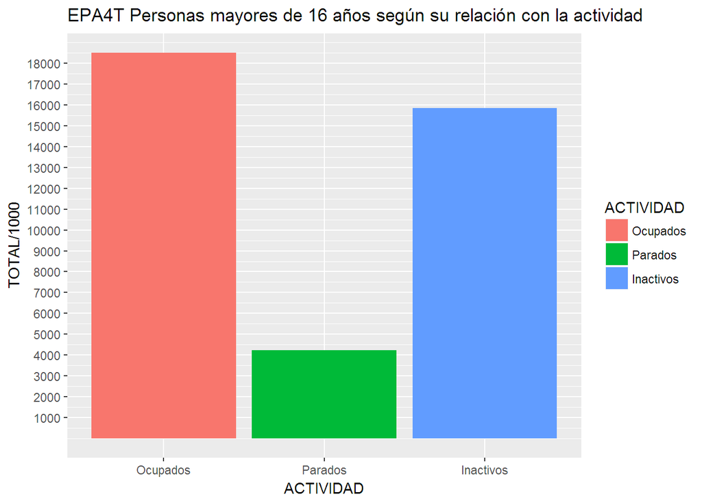

```r
library(ggplot2)
ggplot(tablas_EPA, aes(x=ACTIVIDAD, y=TOTAL/1000, fill=ACTIVIDAD)) + geom_bar(stat="identity")+
  scale_y_continuous(breaks=seq(1000,18000,by=1000))+
ggtitle("EPA4T Personas mayores de 16 años según su relación con la actividad")
```